# Lab 5

Colin Kempf

11/16/2021

```r
acc <- read.csv("https://raw.githubusercontent.com/xdaiISU/ds202materials/master/hwlabs/fars2017/accident.csv", stringsAsFactors = FALSE)
person <- read.csv("https://raw.githubusercontent.com/xdaiISU/ds202materials/master/hwlabs/fars2017/person.csv", stringsAsFactors = FALSE)
library(ggplot2)
library(tidyverse)
library(lubridate)
fatalities <- person %>% filter(INJ_SEV==4)
head(fatalities)
```

```
##   STATE ST_CASE VE_FORMS VEH_NO PER_NO STR_VEH COUNTY DAY MONTH HOUR MINUTE
## 1     1   10001        1      1      1       0     73  19     2   23     35
## 2     1   10002        1      1      1       0     89  14     2   14     59
## 3     1   10003        3      2      1       0    101  31     1   20     31
## 4     1   10004        1      1      1       0     73   1     1   16     55
## 5     1   10005        1      1      1       0     13   1     1   20      0
## 6     1   10006        2      1      1       0     49   6     1   18     40
##   RUR_URB FUNC_SYS HARM_EV MAN_COLL SCH_BUS MAKE MAK_MOD BODY_TYP MOD_YEAR
## 1       2        1      38        0       0   20   20421       15     2004
## 2       2        1       1        0       0   37   37402       14     2005
## 3       2        1      12        1       0    2    2404       14     2003
## 4       2        4      30        0       0   30   30046        4     2014
## 5       1        1      35        0       0   12   12471       34     2010
## 6       1        1      34        0       0   49   49032        4     1997
##   TOW_VEH SPEC_USE EMER_USE ROLLOVER IMPACT1 FIRE_EXP AGE SEX PER_TYP INJ_SEV
```

[output cut: 41 more lines]

```r
dangerVehicles <- fatalities %>% group_by(MAKE) %>% summarise(fatalities = n())
dangerVehicles
```

```
## # A tibble: 66 x 2
##     MAKE fatalities
##    <int>      <int>
##  1     2        692
##  2     3         13
##  3     6        573
##  4     7       1578
##  5     8          1
##  6     9         35
##  7    10          2
##  8    12       3998
##  9    13        207
## 10    14        316
## # ... with 56 more rows
```

```r
dat <- readxl::read_xlsx("FRPP_GLC_-_United_StatesNov42021.xlsx")
dat <- dat %>% rename(STATE="State Code")
dat <- dat %>% rename(NAME="State Name")
dat$STATE <- as.integer(dat$STATE)
statefat <- fatalities %>% select(STATE,MAKE) %>% drop_na(MAKE)
state <- dat %>% group_by(STATE,NAME) %>% distinct(STATE,NAME)
dat3 <- state %>% inner_join(statefat)
makevsfat <- dat3 %>% group_by(NAME,MAKE) %>% summarise(deaths=n()) %>%
  top_n(1, deaths)
```

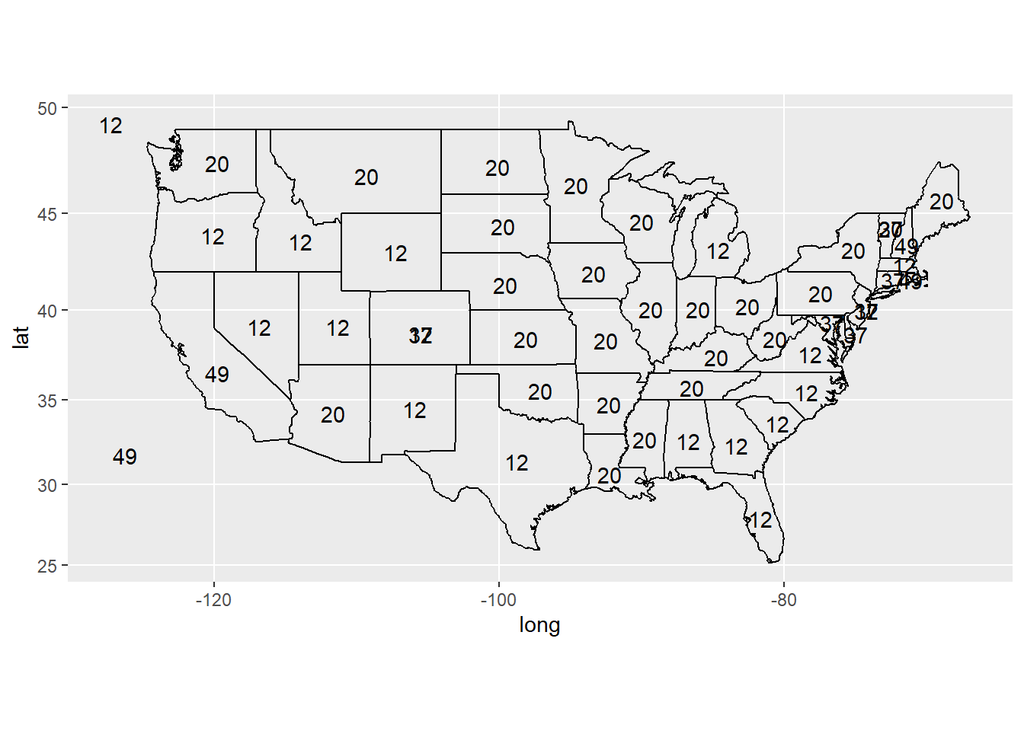

```r
states <- map_data("state")
statenames <- data.frame(region=tolower(state.name), long=state.center$x, lat=state.center$y)
makevsfat <- makevsfat %>% mutate(region = tolower(NAME)) %>% inner_join(statenames)
states %>% ggplot(aes(x = long, y = lat)) +
  geom_path(aes(group = group)) +
  coord_map() +
  geom_text(data=makevsfat, aes(long, lat, label=MAKE))
```

Question 3:

```r
combdat<- person %>% inner_join(acc,by=c("STATE","COUNTY","DAY","MONTH","HOUR","MINUTE"))
head(combdat)
```

```
##   STATE ST_CASE.x VE_FORMS.x VEH_NO PER_NO STR_VEH COUNTY DAY MONTH HOUR MINUTE
## 1     1     10001          1      1      1       0     73  19     2   23     35
## 2     1     10002          1      1      1       0     89  14     2   14     59
## 3     1     10003          3      1      1       0    101  31     1   20     31
## 4     1     10003          3      2      1       0    101  31     1   20     31
## 5     1     10003          3      3      1       0    101  31     1   20     31
## 6     1     10004          1      1      1       0     73   1     1   16     55
##   RUR_URB.x FUNC_SYS.x HARM_EV.x MAN_COLL.x SCH_BUS.x MAKE MAK_MOD BODY_TYP
## 1         2          1        38          0         0   20   20421       15
## 2         2          1         1          0         0   37   37402       14
## 3         2          1        12          1         0   82   82881       66
## 4         2          1        12          1         0    2    2404       14
## 5         2          1        12          1         0   84   84884       66
## 6         2          4        30          0         0   30   30046        4
##   MOD_YEAR TOW_VEH SPEC_USE EMER_USE ROLLOVER IMPACT1 FIRE_EXP AGE SEX PER_TYP
```

[output cut: 76 more lines]

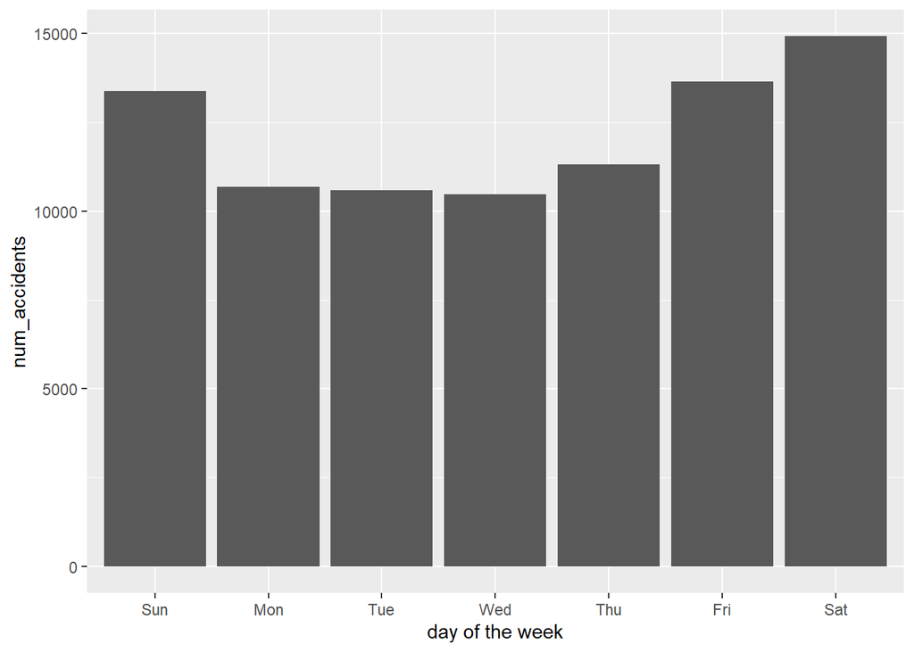

```r
combdat %>% group_by(DAY_WEEK) %>% summarise(num_accidents=n()) %>% mutate(`day of the week`  = wday(DAY_WEEK, label = TRUE)) %>%
  ggplot(aes(x=`day of the week`,y=num_accidents)) + geom_bar(stat = "Identity")
```

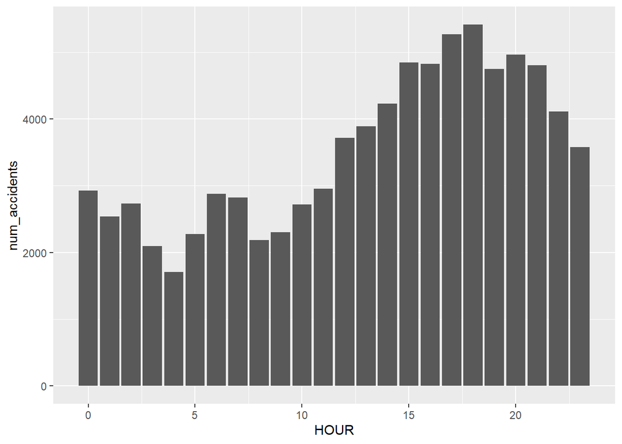

```r
combdat %>% group_by(HOUR) %>% filter(HOUR<25) %>% summarise(num_accidents=n()) %>%
  ggplot(aes(x=HOUR,y=num_accidents)) + geom_bar(stat = "Identity")
```

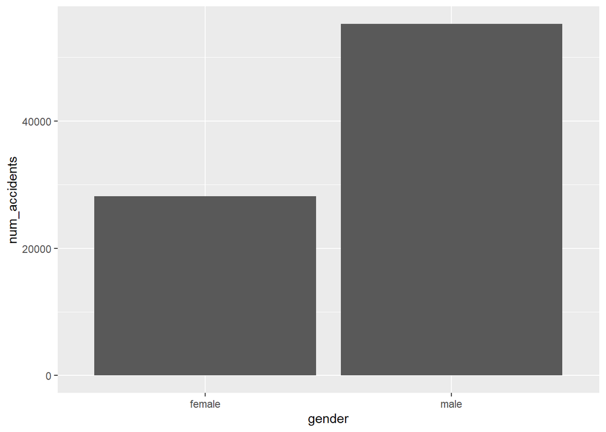

```r
genderdat <- combdat %>%  filter(SEX<3)
genderdat %>% mutate(gender = ifelse(genderdat$SEX == 1, "male", "female")) %>% group_by(gender)  %>% summarise(num_accidents=n()) %>%
  ggplot(aes(x=gender,y=num_accidents)) + geom_bar(stat = "Identity")
```

Question 5:

For the days of the week, the graph shows the number of accidents increasing as the weekend comes. This makes sense as more people are going out and driving around.

Looking at the hours, the graph shows the number of accidents increasing towards the afternoon and evening. This makes sense as more and more people get off work, and begin to drive home, before starting things like errands or going to activities, all of which require driving to.

Looking at gender, the graph shows the number of accidents is nearly doubled for men than it is women. The reasoning for this could be for a number of reasons and is hard to estimate. It could be that men just drive less careful, or are more likely to break traffic laws.

```r
dat <- dat %>% rename(COUNTY="County Code")
dat <- dat %>% rename(CN="County Name")
dat$COUNTY <- as.integer(dat$COUNTY)
dat6 <- fatalities %>% select(COUNTY) %>% drop_na(COUNTY)
county <- dat %>% group_by(COUNTY,CN) %>% distinct(COUNTY,CN)

dat6 <- county %>% inner_join(dat6) %>% summarise(deaths=n())
```

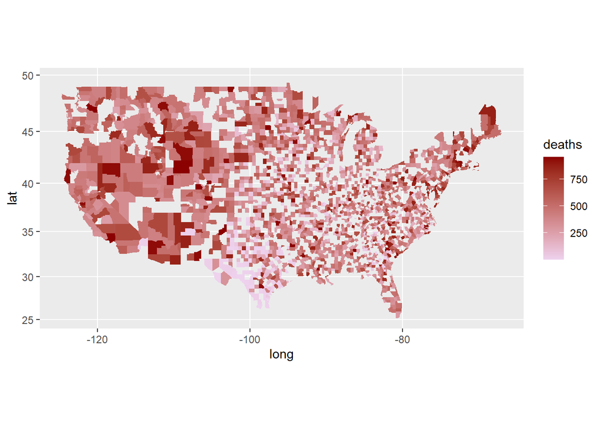

```r
counties <- map_data("county")
counties <- dat6 %>% mutate(subregion=tolower(CN)) %>% inner_join(counties, by="subregion")
counties %>% ggplot(aes(x = long, y = lat)) +
  geom_polygon(aes(group = group,fill=deaths)) +
  coord_map()+scale_fill_continuous(low="thistle2", high="darkred",
                       guide="colorbar",na.value="white")
```

Question 6: